# Week 6 - Midterm Assignment: A Simulation Project

STAT 420, Summer 2021,Alejandro Pimentel (ap41)

# Simulation Study 1: Significance of Regression

## Introduction

In this simulation study we will investigate the significance of regression test. We will simulate from two different models:

1. The **“significant”** model

$$Y_i = \beta_0 + \beta_1 x_{i1} + \beta_2 x_{i2} + \beta_3 x_{i3} + \epsilon_i$$

where $\epsilon_i \sim N(0, \sigma^2)$ and

- $\beta_0 = 3$,
- $\beta_1 = 1$,
- $\beta_2 = 1$,
- $\beta_3 = 1$.
2. The **“non-significant”** model

$$Y_i = \beta_0 + \beta_1 x_{i1} + \beta_2 x_{i2} + \beta_3 x_{i3} + \epsilon_i$$

where $\epsilon_i \sim N(0, \sigma^2)$ and

- $\beta_0 = 3$,
- $\beta_1 = 0$,
- $\beta_2 = 0$,
- $\beta_3 = 0$.

For both, we will consider a sample size of $25$ and three possible levels of noise. That is, three values of $\sigma$.

- $n = 25$
- $\sigma \in (1, 5, 10)$

## Methods

Read the `csv` file with our samples and take a look to some of them.

```r
library(readr)
study1_data <- read_csv("./study_1.csv")

head(study1_data)
```

```
## # A tibble: 6 x 4
##       y    x1    x2    x3
##   <dbl> <dbl> <dbl> <dbl>
## 1     0 -1.54   3    2.96
## 2     0 -1.61   2.9  2.71
## 3     0 -4.56   2.9  2.62
## 4     0 -2.28   2.5  2.41
## 5     0 -2.76   3    2.77
## 6     0 -3.01   2.9  2.28
```

```r
# Set a seed to have a stable generation of random numbers
birthday = 19820426
set.seed(birthday)
```

For the simulations we need to define a few functions.

First, a function to generate the responses $y$. For which we need:

- A matrix with the predictors values.
- A matrix of `p` by 1 where `p` is the number of parameters `beta` in the model.
- A `sigma` to generate noise ($\epsilon$) to the response.

The output is a data frame with all predictors and `y` values added.

```r
generate_mlr_data <- function(X, betas, sigma = 1) {
  n <- nrow(X)
  epsilon <- rnorm(n = n, mean = 0, sd = sigma)
  X_full <- as.matrix(cbind(1, X))
  X$y <- (X_full %*% betas) + epsilon
  as.data.frame(X)
}
```

Next, we need a function that runs a number of simulations with a fixed $\beta_i$ values and `sigma`. For each `fitted model` the function extracts:

- The **$F$ statistic** for the significance of regression test.
- The **p-value** for the significance of regression test
- **$R^2$**

```r
loop_simulation <- function (X, betas, num_simulations = 2000, sigma = 1) {
  fstats <- rep(0, num_simulations)
  pvals <- rep(0, num_simulations)
  r2s <- rep(0, num_simulations)
  for (i in 1:num_simulations) {
    sim_data <- generate_mlr_data(X, matrix(betas), sigma)
    sim_model <- lm(y ~ ., data = sim_data)
    ft <- unname(summary(sim_model)$fstatistic)
    fstats[i] <- ft[1]
    pvals[i] <- 1 - pf(ft[1], df1 = ft[2], df2 = ft[3])
    r2s[i] <- summary(sim_model)$r.squared
  }
  list(
    fstats = fstats,
    pvals = pvals,
    r2s = r2s
    )
}
```

We are set to run the 6 simulations, the code below does it.

```r
# Only take the predictor columns x_i
X <- study1_data[, 2:4]
# The beta values for the significant model
sig_betas <- c(3, 1, 1, 1)
# The beta values for the non-significant model
nosig_betas <- c(3, 0, 0, 0)
# The 3 sigma values to use on each model
sigma_1 <- 1
sigma_5 <- 5
sigma_10 <- 10

num_sims <- 200

# Simulations for the significant model
signif_1 <- loop_simulation(X, sig_betas, num_simulations = num_sims, sigma_1)
signif_5 <- loop_simulation(X, sig_betas, num_simulations = num_sims, sigma_5)
signif_10 <- loop_simulation(X, sig_betas, num_simulations = num_sims, sigma_10)

# Simulations for the non-significant model
nosignif_1 <- loop_simulation(X, nosig_betas, num_simulations = num_sims, sigma_1)
nosignif_5 <- loop_simulation(X, nosig_betas, num_simulations = num_sims, sigma_5)
nosignif_10 <- loop_simulation(X, nosig_betas, num_simulations = num_sims, sigma_10)
```

## Results

Here we present a collection of graph to analyze the simulation results. To keep things DRY I define a function that shows:

- A histogram of the `f statistic` values obtained in the simulation.
- The `true` curve of the distribution given the degrees of freedom in our model (when the distribution is known).

```r
graph_helper <- function(simuldata, sigma, dist_curve = "", color, title) {
  hist(simuldata, probability = TRUE, breaks = 15,
     xlab = title,
     main = paste(title," ( sigma =", sigma,")"),
     col = color,
     border = "aliceblue")

  if(dist_curve == "f") {
    curve(df(x, df1 = 4 - 1, df2 = 25 - 4),
        col = "darkorange",
        add = TRUE, lwd = 3
        )
  }

  if(dist_curve == "unif") {
    curve(dunif(x),
      col = "darkorange",
      add = TRUE, lwd = 3
      )
  }

  if(dist_curve != "") {
    legend("topright", c("Simulated", "Real"),
         lty = c(1, 2),
         lwd = 3,
         col = c(color, "darkorange"))
  }
}
```

**Graph 1.1 - F Statistics for the `significant model` on each $\sigma$**

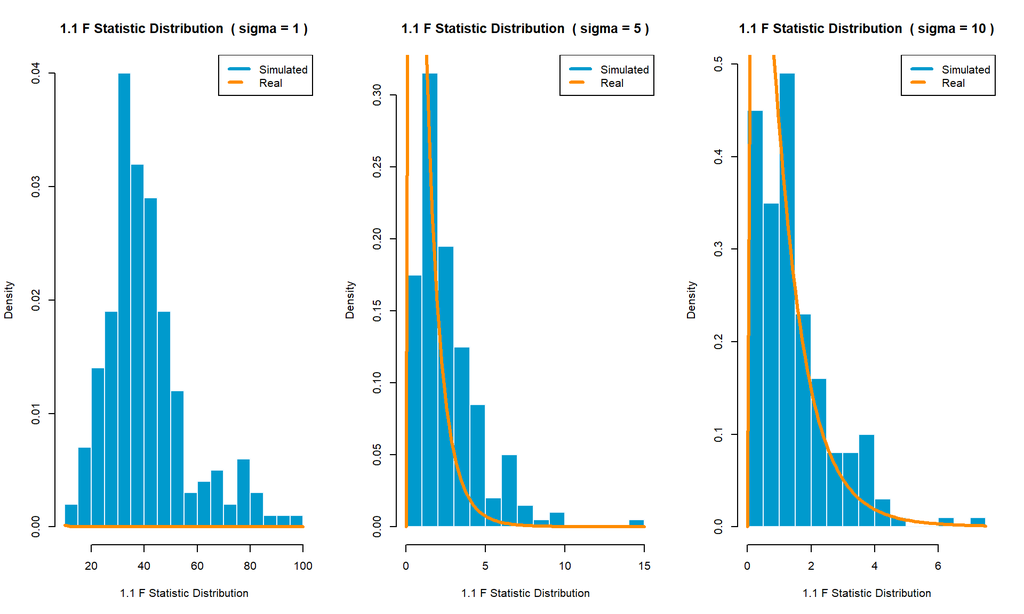

```r
par(mfrow=c(1, 3))
title <- "1.1 F Statistic Distribution"
graph_helper(signif_1$fstats, sigma_1, "f", color = "deepskyblue3", title)
graph_helper(signif_5$fstats, sigma_5, "f", color = "deepskyblue3", title)
graph_helper(signif_10$fstats, sigma_10, "f", color = "deepskyblue3", title)
```

**Graph 1.2 - F Statistics for the `non-significant model` on each $\sigma$**

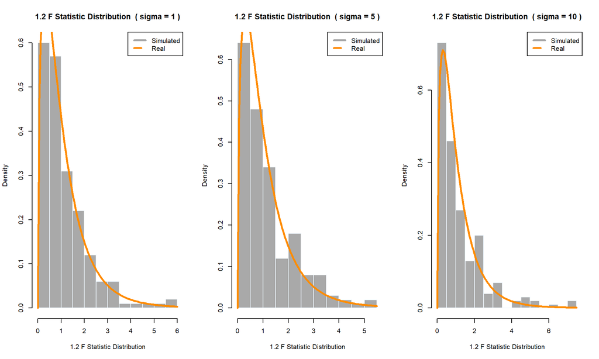

```r
par(mfrow=c(1, 3))
title <- "1.2 F Statistic Distribution"
graph_helper(nosignif_1$fstats, sigma_1, "f", color = "darkgray", title)
graph_helper(nosignif_5$fstats, sigma_5, "f", color = "darkgray", title)
graph_helper(nosignif_10$fstats, sigma_10, "f", color = "darkgray", title)
```

**Graph 2.1 - p-values for the `significant model` on each $\sigma$**

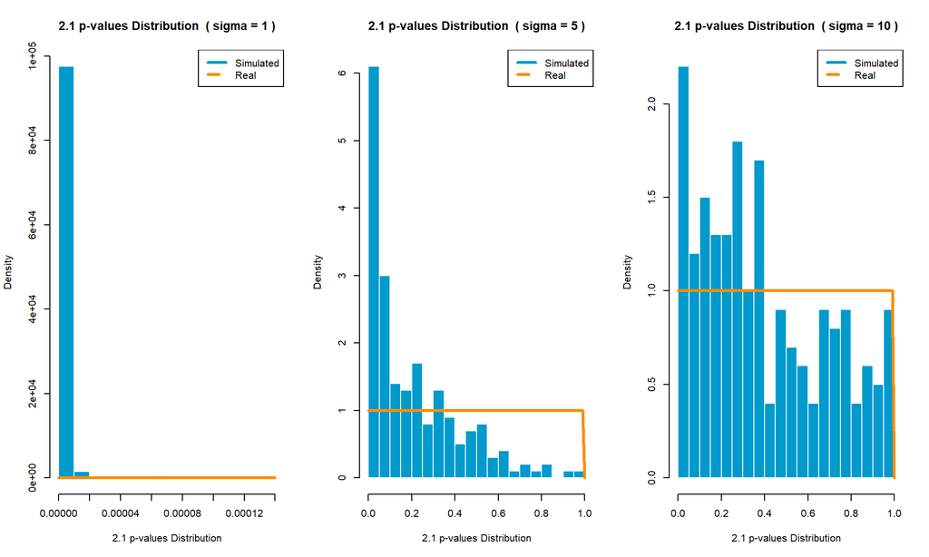

```r
par(mfrow=c(1, 3))
title <- "2.1 p-values Distribution"
graph_helper(signif_1$pvals, sigma_1, "unif", color = "deepskyblue3", title)
graph_helper(signif_5$pvals, sigma_5, "unif", color = "deepskyblue3", title)
graph_helper(signif_10$pvals, sigma_10, "unif", color = "deepskyblue3", title)
```

**Graph 2.2 - p-values for the `non-significant model` on each $\sigma$**

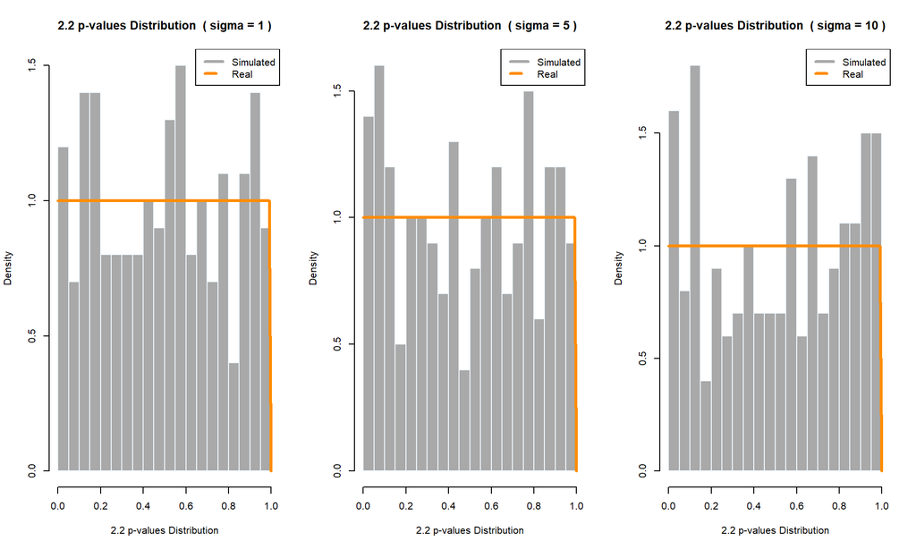

```r
par(mfrow=c(1, 3))
title <- "2.2 p-values Distribution"
graph_helper(nosignif_1$pvals, sigma_1, "unif", color = "darkgray", title)
graph_helper(nosignif_5$pvals, sigma_5, "unif", color = "darkgray", title)
graph_helper(nosignif_10$pvals, sigma_10, "unif", color = "darkgray", title)
```

**Graph 3.1 - $R^2$ for the `significant model` on each $\sigma$**

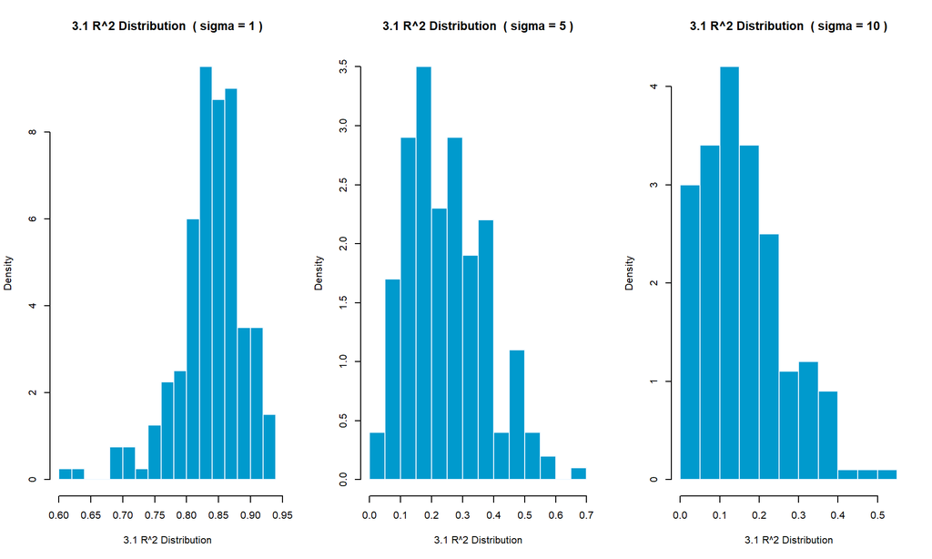

```r
par(mfrow=c(1, 3))
title <- "3.1 R^2 Distribution"
graph_helper(signif_1$r2s, sigma_1, color = "deepskyblue3", title = title)
graph_helper(signif_5$r2s, sigma_5, color = "deepskyblue3", title = title)
graph_helper(signif_10$r2s, sigma_10, color = "deepskyblue3", title = title)
```

**Graph 3.2 - $R^2$ for the `non-significant model` on each $\sigma$**

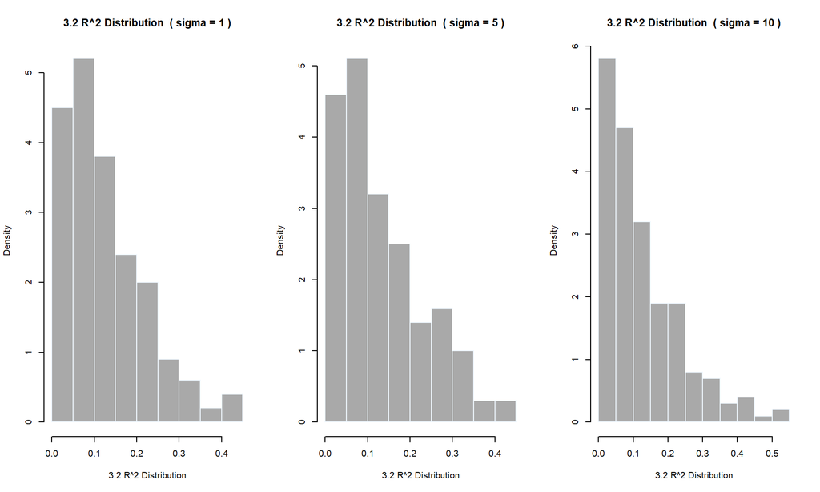

```r
par(mfrow=c(1, 3))
title <- "3.2 R^2 Distribution"
graph_helper(nosignif_1$r2s, sigma_1, color = "darkgray", title = title)
graph_helper(nosignif_5$r2s, sigma_5, color = "darkgray", title = title)
graph_helper(nosignif_10$r2s, sigma_10, color = "darkgray", title = title)
```